# Risk Factor Analysis

## Outcome Variable

**Outcome Variable:** wast_rec90d

## Predictor Variables

**Intervention Variable:** enstunt

**Adjustment Set:**

- arm
- sex
- W_mage
- meducyrs
- feducyrs
- vagbrth
- brthmon
- W_parity
- delta_W_mage
- delta_meducyrs
- delta_feducyrs
- delta_vagbrth
- delta_brthmon
- delta_W_parity

## Stratifying Variables

The analysis was stratified on these variable(s):

- agecat
- studyid
- country

## Data Summary

| agecat | studyid | country | enstunt | wast_rec90d | n_cell | n |
| --- | --- | --- | --- | --- | --- | --- |
| 0-24 months | ki0047075b-MAL-ED | BANGLADESH | 0 | 0 | 34 | 124 |
| 0-24 months | ki0047075b-MAL-ED | BANGLADESH | 0 | 1 | 61 | 124 |
| 0-24 months | ki0047075b-MAL-ED | BANGLADESH | 1 | 0 | 11 | 124 |
| 0-24 months | ki0047075b-MAL-ED | BANGLADESH | 1 | 1 | 18 | 124 |
| 0-24 months | ki0047075b-MAL-ED | BRAZIL | 0 | 0 | 5 | 23 |
| 0-24 months | ki0047075b-MAL-ED | BRAZIL | 0 | 1 | 15 | 23 |
| 0-24 months | ki0047075b-MAL-ED | BRAZIL | 1 | 0 | 1 | 23 |
| 0-24 months | ki0047075b-MAL-ED | BRAZIL | 1 | 1 | 2 | 23 |
| 0-24 months | ki0047075b-MAL-ED | INDIA | 0 | 0 | 51 | 178 |
| 0-24 months | ki0047075b-MAL-ED | INDIA | 0 | 1 | 89 | 178 |
| 0-24 months | ki0047075b-MAL-ED | INDIA | 1 | 0 | 20 | 178 |
| 0-24 months | ki0047075b-MAL-ED | INDIA | 1 | 1 | 18 | 178 |
| 0-24 months | ki0047075b-MAL-ED | NEPAL | 0 | 0 | 16 | 93 |
| 0-24 months | ki0047075b-MAL-ED | NEPAL | 0 | 1 | 59 | 93 |
| 0-24 months | ki0047075b-MAL-ED | NEPAL | 1 | 0 | 4 | 93 |
| 0-24 months | ki0047075b-MAL-ED | NEPAL | 1 | 1 | 14 | 93 |
| 0-24 months | ki0047075b-MAL-ED | PERU | 0 | 0 | 3 | 34 |
| 0-24 months | ki0047075b-MAL-ED | PERU | 0 | 1 | 20 | 34 |
| 0-24 months | ki0047075b-MAL-ED | PERU | 1 | 0 | 3 | 34 |
| 0-24 months | ki0047075b-MAL-ED | PERU | 1 | 1 | 8 | 34 |
| 0-24 months | ki0047075b-MAL-ED | SOUTH AFRICA | 0 | 0 | 16 | 83 |
| 0-24 months | ki0047075b-MAL-ED | SOUTH AFRICA | 0 | 1 | 54 | 83 |
| 0-24 months | ki0047075b-MAL-ED | SOUTH AFRICA | 1 | 0 | 1 | 83 |
| 0-24 months | ki0047075b-MAL-ED | SOUTH AFRICA | 1 | 1 | 12 | 83 |
| 0-24 months | ki0047075b-MAL-ED | TANZANIA, UNITED REPUBLIC OF | 0 | 0 | 7 | 45 |
| 0-24 months | ki0047075b-MAL-ED | TANZANIA, UNITED REPUBLIC OF | 0 | 1 | 28 | 45 |
| 0-24 months | ki0047075b-MAL-ED | TANZANIA, UNITED REPUBLIC OF | 1 | 0 | 1 | 45 |
| 0-24 months | ki0047075b-MAL-ED | TANZANIA, UNITED REPUBLIC OF | 1 | 1 | 9 | 45 |
| 0-24 months | ki1000108-CMC-V-BCS-2002 | INDIA | 0 | 0 | 88 | 326 |
| 0-24 months | ki1000108-CMC-V-BCS-2002 | INDIA | 0 | 1 | 163 | 326 |

[output cut: 374 more lines]

The following strata were considered:

- agecat: 0-24 months, studyid: ki0047075b-MAL-ED, country: BANGLADESH
- agecat: 0-24 months, studyid: ki0047075b-MAL-ED, country: BRAZIL
- agecat: 0-24 months, studyid: ki0047075b-MAL-ED, country: INDIA
- agecat: 0-24 months, studyid: ki0047075b-MAL-ED, country: NEPAL
- agecat: 0-24 months, studyid: ki0047075b-MAL-ED, country: PERU
- agecat: 0-24 months, studyid: ki0047075b-MAL-ED, country: SOUTH AFRICA
- agecat: 0-24 months, studyid: ki0047075b-MAL-ED, country: TANZANIA, UNITED REPUBLIC OF
- agecat: 0-24 months, studyid: ki1000108-CMC-V-BCS-2002, country: INDIA
- agecat: 0-24 months, studyid: ki1000108-IRC, country: INDIA
- agecat: 0-24 months, studyid: ki1000109-EE, country: PAKISTAN
- agecat: 0-24 months, studyid: ki1000109-ResPak, country: PAKISTAN
- agecat: 0-24 months, studyid: ki1000304b-SAS-CompFeed, country: INDIA
- agecat: 0-24 months, studyid: ki1000304b-SAS-FoodSuppl, country: INDIA
- agecat: 0-24 months, studyid: ki1017093-NIH-Birth, country: BANGLADESH
- agecat: 0-24 months, studyid: ki1017093b-PROVIDE, country: BANGLADESH
- agecat: 0-24 months, studyid: ki1017093c-NIH-Crypto, country: BANGLADESH
- agecat: 0-24 months, studyid: ki1066203-TanzaniaChild2, country: TANZANIA, UNITED REPUBLIC OF
- agecat: 0-24 months, studyid: ki1101329-Keneba, country: GAMBIA
- agecat: 0-24 months, studyid: ki1112895-Guatemala BSC, country: GUATEMALA
- agecat: 0-24 months, studyid: ki1112895-iLiNS-Zinc, country: BURKINA FASO
- agecat: 0-24 months, studyid: ki1113344-GMS-Nepal, country: NEPAL
- agecat: 0-24 months, studyid: ki1114097-CMIN, country: BANGLADESH
- agecat: 0-24 months, studyid: ki1114097-CMIN, country: BRAZIL
- agecat: 0-24 months, studyid: ki1114097-CMIN, country: GUINEA-BISSAU
- agecat: 0-24 months, studyid: ki1114097-CMIN, country: PERU
- agecat: 0-24 months, studyid: ki1114097-CONTENT, country: PERU
- agecat: 0-24 months, studyid: ki1119695-PROBIT, country: BELARUS
- agecat: 0-24 months, studyid: ki1126311-ZVITAMBO, country: ZIMBABWE
- agecat: 0-24 months, studyid: ki1135781-COHORTS, country: GUATEMALA
- agecat: 0-24 months, studyid: ki1135781-COHORTS, country: INDIA
- agecat: 0-24 months, studyid: ki1135781-COHORTS, country: PHILIPPINES
- agecat: 0-24 months, studyid: ki1148112-LCNI-5, country: MALAWI
- agecat: 0-24 months, studyid: kiGH5241-JiVitA-3, country: BANGLADESH
- agecat: 0-24 months, studyid: kiGH5241-JiVitA-4, country: BANGLADESH
- agecat: 0-6 months, studyid: ki0047075b-MAL-ED, country: BANGLADESH
- agecat: 0-6 months, studyid: ki0047075b-MAL-ED, country: BRAZIL
- agecat: 0-6 months, studyid: ki0047075b-MAL-ED, country: INDIA
- agecat: 0-6 months, studyid: ki0047075b-MAL-ED, country: NEPAL
- agecat: 0-6 months, studyid: ki0047075b-MAL-ED, country: PERU
- agecat: 0-6 months, studyid: ki0047075b-MAL-ED, country: SOUTH AFRICA
- agecat: 0-6 months, studyid: ki0047075b-MAL-ED, country: TANZANIA, UNITED REPUBLIC OF
- agecat: 0-6 months, studyid: ki1000108-CMC-V-BCS-2002, country: INDIA
- agecat: 0-6 months, studyid: ki1000108-IRC, country: INDIA
- agecat: 0-6 months, studyid: ki1000109-EE, country: PAKISTAN
- agecat: 0-6 months, studyid: ki1000109-ResPak, country: PAKISTAN
- agecat: 0-6 months, studyid: ki1000304b-SAS-CompFeed, country: INDIA
- agecat: 0-6 months, studyid: ki1000304b-SAS-FoodSuppl, country: INDIA
- agecat: 0-6 months, studyid: ki1017093-NIH-Birth, country: BANGLADESH
- agecat: 0-6 months, studyid: ki1017093b-PROVIDE, country: BANGLADESH
- agecat: 0-6 months, studyid: ki1017093c-NIH-Crypto, country: BANGLADESH
- agecat: 0-6 months, studyid: ki1066203-TanzaniaChild2, country: TANZANIA, UNITED REPUBLIC OF
- agecat: 0-6 months, studyid: ki1101329-Keneba, country: GAMBIA
- agecat: 0-6 months, studyid: ki1112895-Guatemala BSC, country: GUATEMALA
- agecat: 0-6 months, studyid: ki1113344-GMS-Nepal, country: NEPAL
- agecat: 0-6 months, studyid: ki1114097-CMIN, country: BANGLADESH
- agecat: 0-6 months, studyid: ki1114097-CMIN, country: BRAZIL
- agecat: 0-6 months, studyid: ki1114097-CMIN, country: GUINEA-BISSAU
- agecat: 0-6 months, studyid: ki1114097-CMIN, country: PERU
- agecat: 0-6 months, studyid: ki1114097-CONTENT, country: PERU
- agecat: 0-6 months, studyid: ki1119695-PROBIT, country: BELARUS
- agecat: 0-6 months, studyid: ki1126311-ZVITAMBO, country: ZIMBABWE
- agecat: 0-6 months, studyid: ki1135781-COHORTS, country: GUATEMALA
- agecat: 0-6 months, studyid: ki1135781-COHORTS, country: INDIA
- agecat: 0-6 months, studyid: ki1135781-COHORTS, country: PHILIPPINES
- agecat: 0-6 months, studyid: ki1148112-LCNI-5, country: MALAWI
- agecat: 0-6 months, studyid: kiGH5241-JiVitA-3, country: BANGLADESH
- agecat: 0-6 months, studyid: kiGH5241-JiVitA-4, country: BANGLADESH
- agecat: 6-24 months, studyid: ki0047075b-MAL-ED, country: BANGLADESH
- agecat: 6-24 months, studyid: ki0047075b-MAL-ED, country: BRAZIL
- agecat: 6-24 months, studyid: ki0047075b-MAL-ED, country: INDIA
- agecat: 6-24 months, studyid: ki0047075b-MAL-ED, country: NEPAL
- agecat: 6-24 months, studyid: ki0047075b-MAL-ED, country: PERU
- agecat: 6-24 months, studyid: ki0047075b-MAL-ED, country: SOUTH AFRICA
- agecat: 6-24 months, studyid: ki0047075b-MAL-ED, country: TANZANIA, UNITED REPUBLIC OF
- agecat: 6-24 months, studyid: ki1000108-CMC-V-BCS-2002, country: INDIA
- agecat: 6-24 months, studyid: ki1000108-IRC, country: INDIA
- agecat: 6-24 months, studyid: ki1000109-EE, country: PAKISTAN
- agecat: 6-24 months, studyid: ki1000109-ResPak, country: PAKISTAN
- agecat: 6-24 months, studyid: ki1000304b-SAS-CompFeed, country: INDIA
- agecat: 6-24 months, studyid: ki1000304b-SAS-FoodSuppl, country: INDIA
- agecat: 6-24 months, studyid: ki1017093-NIH-Birth, country: BANGLADESH
- agecat: 6-24 months, studyid: ki1017093b-PROVIDE, country: BANGLADESH
- agecat: 6-24 months, studyid: ki1017093c-NIH-Crypto, country: BANGLADESH
- agecat: 6-24 months, studyid: ki1066203-TanzaniaChild2, country: TANZANIA, UNITED REPUBLIC OF
- agecat: 6-24 months, studyid: ki1101329-Keneba, country: GAMBIA
- agecat: 6-24 months, studyid: ki1112895-Guatemala BSC, country: GUATEMALA
- agecat: 6-24 months, studyid: ki1112895-iLiNS-Zinc, country: BURKINA FASO
- agecat: 6-24 months, studyid: ki1113344-GMS-Nepal, country: NEPAL
- agecat: 6-24 months, studyid: ki1114097-CMIN, country: BANGLADESH
- agecat: 6-24 months, studyid: ki1114097-CMIN, country: BRAZIL
- agecat: 6-24 months, studyid: ki1114097-CMIN, country: GUINEA-BISSAU
- agecat: 6-24 months, studyid: ki1114097-CMIN, country: PERU
- agecat: 6-24 months, studyid: ki1114097-CONTENT, country: PERU
- agecat: 6-24 months, studyid: ki1119695-PROBIT, country: BELARUS
- agecat: 6-24 months, studyid: ki1126311-ZVITAMBO, country: ZIMBABWE
- agecat: 6-24 months, studyid: ki1135781-COHORTS, country: GUATEMALA
- agecat: 6-24 months, studyid: ki1135781-COHORTS, country: INDIA
- agecat: 6-24 months, studyid: ki1135781-COHORTS, country: PHILIPPINES
- agecat: 6-24 months, studyid: ki1148112-LCNI-5, country: MALAWI
- agecat: 6-24 months, studyid: kiGH5241-JiVitA-3, country: BANGLADESH
- agecat: 6-24 months, studyid: kiGH5241-JiVitA-4, country: BANGLADESH

### Dropped Strata

Some strata were dropped due to rare outcomes:

- agecat: 0-24 months, studyid: ki0047075b-MAL-ED, country: BRAZIL
- agecat: 0-24 months, studyid: ki0047075b-MAL-ED, country: NEPAL
- agecat: 0-24 months, studyid: ki0047075b-MAL-ED, country: PERU
- agecat: 0-24 months, studyid: ki0047075b-MAL-ED, country: SOUTH AFRICA
- agecat: 0-24 months, studyid: ki0047075b-MAL-ED, country: TANZANIA, UNITED REPUBLIC OF
- agecat: 0-24 months, studyid: ki1000304b-SAS-FoodSuppl, country: INDIA
- agecat: 0-24 months, studyid: ki1114097-CMIN, country: BRAZIL
- agecat: 0-24 months, studyid: ki1114097-CONTENT, country: PERU
- agecat: 0-24 months, studyid: ki1119695-PROBIT, country: BELARUS
- agecat: 0-24 months, studyid: ki1135781-COHORTS, country: GUATEMALA
- agecat: 0-6 months, studyid: ki0047075b-MAL-ED, country: BANGLADESH
- agecat: 0-6 months, studyid: ki0047075b-MAL-ED, country: BRAZIL
- agecat: 0-6 months, studyid: ki0047075b-MAL-ED, country: INDIA
- agecat: 0-6 months, studyid: ki0047075b-MAL-ED, country: NEPAL
- agecat: 0-6 months, studyid: ki0047075b-MAL-ED, country: PERU
- agecat: 0-6 months, studyid: ki0047075b-MAL-ED, country: SOUTH AFRICA
- agecat: 0-6 months, studyid: ki0047075b-MAL-ED, country: TANZANIA, UNITED REPUBLIC OF
- agecat: 0-6 months, studyid: ki1000304b-SAS-FoodSuppl, country: INDIA
- agecat: 0-6 months, studyid: ki1017093c-NIH-Crypto, country: BANGLADESH
- agecat: 0-6 months, studyid: ki1066203-TanzaniaChild2, country: TANZANIA, UNITED REPUBLIC OF
- agecat: 0-6 months, studyid: ki1112895-Guatemala BSC, country: GUATEMALA
- agecat: 0-6 months, studyid: ki1114097-CMIN, country: BRAZIL
- agecat: 0-6 months, studyid: ki1114097-CMIN, country: GUINEA-BISSAU
- agecat: 0-6 months, studyid: ki1114097-CMIN, country: PERU
- agecat: 0-6 months, studyid: ki1114097-CONTENT, country: PERU
- agecat: 0-6 months, studyid: ki1119695-PROBIT, country: BELARUS
- agecat: 0-6 months, studyid: ki1135781-COHORTS, country: GUATEMALA
- agecat: 0-6 months, studyid: ki1148112-LCNI-5, country: MALAWI
- agecat: 6-24 months, studyid: ki0047075b-MAL-ED, country: BRAZIL
- agecat: 6-24 months, studyid: ki0047075b-MAL-ED, country: NEPAL
- agecat: 6-24 months, studyid: ki0047075b-MAL-ED, country: PERU
- agecat: 6-24 months, studyid: ki0047075b-MAL-ED, country: SOUTH AFRICA
- agecat: 6-24 months, studyid: ki0047075b-MAL-ED, country: TANZANIA, UNITED REPUBLIC OF
- agecat: 6-24 months, studyid: ki1000304b-SAS-FoodSuppl, country: INDIA
- agecat: 6-24 months, studyid: ki1017093c-NIH-Crypto, country: BANGLADESH
- agecat: 6-24 months, studyid: ki1114097-CMIN, country: BRAZIL
- agecat: 6-24 months, studyid: ki1114097-CONTENT, country: PERU
- agecat: 6-24 months, studyid: ki1119695-PROBIT, country: BELARUS
- agecat: 6-24 months, studyid: ki1135781-COHORTS, country: GUATEMALA
- agecat: 6-24 months, studyid: ki1135781-COHORTS, country: INDIA
- agecat: 6-24 months, studyid: kiGH5241-JiVitA-3, country: BANGLADESH

## Methods Detail

We’re interested in the causal parameters $E[Y_a]$ for all values of $a \in \mathcal{A}$. These parameters represent the mean outcome if, possibly contrary to fact, we intervened to set all units to have $A=a$. Under the randomization and positivity assumptions, these are identified by the statistical parameters $\psi_a=E_W[E_{Y|A,W}(Y|A=a,W)]$. In addition, we’re interested in the mean of $Y$, $E[Y]$ under no intervention (the observed mean). We will estimate these parameters by using SuperLearner to fit the relevant likelihood factors – $E_{Y|A,W}(Y|A=a,W)$ and $p(A=a|W)$, and then updating our likelihood fit using a joint TMLE.

For unadjusted analyses ($W=\{\}$), initial likelihoods were estimated using Lrnr_glm to estimate the simple $E(Y|A)$ and Lrnr_mean to estimate $p(A)$. For adjusted analyses, a small library containing Lrnr_glmnet, Lrnr_xgboost, and Lrnr_mean was used.

Having estimated these parameters, we will then use the delta method to estimate relative risks and attributable risks relative to a prespecified baseline level of $A$.

# Results Detail

## Results Plots

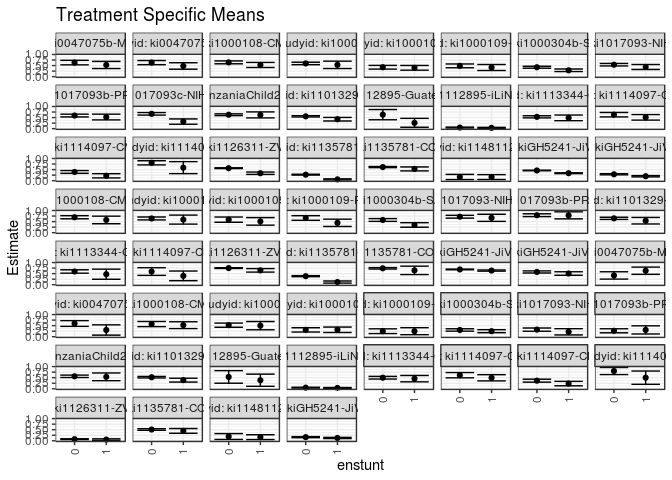

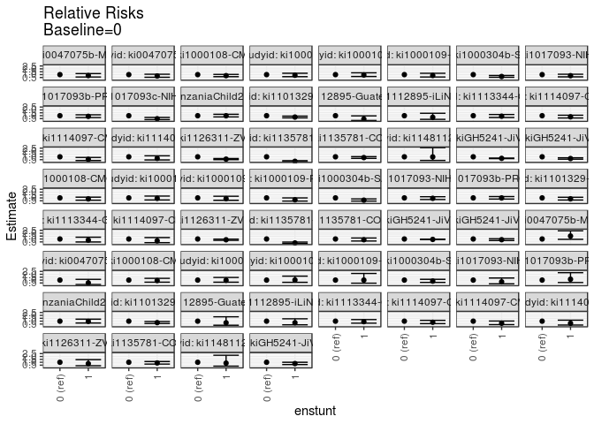

[figure not shown]

[figure not shown]

## Results Table

### Parameter: TSM

| agecat | studyid | country | intervention_level | baseline_level | estimate | ci_lower | ci_upper |
| --- | --- | --- | --- | --- | --- | --- | --- |
| 0-24 months | ki0047075b-MAL-ED | BANGLADESH | 0 | NA | 0.6339437 | 0.5326284 | 0.7352591 |
| 0-24 months | ki0047075b-MAL-ED | BANGLADESH | 1 | NA | 0.5264394 | 0.3653917 | 0.6874872 |
| 0-24 months | ki0047075b-MAL-ED | INDIA | 0 | NA | 0.6330783 | 0.5397213 | 0.7264354 |
| 0-24 months | ki0047075b-MAL-ED | INDIA | 1 | NA | 0.4810158 | 0.3350092 | 0.6270224 |
| 0-24 months | ki1000108-CMC-V-BCS-2002 | INDIA | 0 | NA | 0.6435912 | 0.5791168 | 0.7080655 |
| 0-24 months | ki1000108-CMC-V-BCS-2002 | INDIA | 1 | NA | 0.5265898 | 0.4117697 | 0.6414099 |
| 0-24 months | ki1000108-IRC | INDIA | 0 | NA | 0.5955200 | 0.5399995 | 0.6510406 |
| 0-24 months | ki1000108-IRC | INDIA | 1 | NA | 0.5315121 | 0.3659423 | 0.6970820 |
| 0-24 months | ki1000109-EE | PAKISTAN | 0 | NA | 0.4231180 | 0.3398321 | 0.5064040 |
| 0-24 months | ki1000109-EE | PAKISTAN | 1 | NA | 0.3975264 | 0.2911632 | 0.5038896 |
| 0-24 months | ki1000109-ResPak | PAKISTAN | 0 | NA | 0.4861535 | 0.4003896 | 0.5719174 |
| 0-24 months | ki1000109-ResPak | PAKISTAN | 1 | NA | 0.4119296 | 0.2771723 | 0.5466869 |
| 0-24 months | ki1000304b-SAS-CompFeed | INDIA | 0 | NA | 0.4239645 | 0.3805356 | 0.4673933 |
| 0-24 months | ki1000304b-SAS-CompFeed | INDIA | 1 | NA | 0.2868575 | 0.2290800 | 0.3446350 |
| 0-24 months | ki1017093-NIH-Birth | BANGLADESH | 0 | NA | 0.5373525 | 0.4807254 | 0.5939795 |
| 0-24 months | ki1017093-NIH-Birth | BANGLADESH | 1 | NA | 0.4354942 | 0.3237200 | 0.5472684 |
| 0-24 months | ki1017093b-PROVIDE | BANGLADESH | 0 | NA | 0.5914082 | 0.5284876 | 0.6543287 |
| 0-24 months | ki1017093b-PROVIDE | BANGLADESH | 1 | NA | 0.5244234 | 0.3956982 | 0.6531487 |
| 0-24 months | ki1017093c-NIH-Crypto | BANGLADESH | 0 | NA | 0.6679237 | 0.6102842 | 0.7255632 |
| 0-24 months | ki1017093c-NIH-Crypto | BANGLADESH | 1 | NA | 0.3184011 | 0.1986109 | 0.4381914 |
| 0-24 months | ki1066203-TanzaniaChild2 | TANZANIA, UNITED REPUBLIC OF | 0 | NA | 0.6274529 | 0.5882100 | 0.6666957 |
| 0-24 months | ki1066203-TanzaniaChild2 | TANZANIA, UNITED REPUBLIC OF | 1 | NA | 0.6209545 | 0.4855548 | 0.7563541 |
| 0-24 months | ki1101329-Keneba | GAMBIA | 0 | NA | 0.5553628 | 0.5263389 | 0.5843868 |
| 0-24 months | ki1101329-Keneba | GAMBIA | 1 | NA | 0.4254278 | 0.3452717 | 0.5055840 |
| 0-24 months | ki1112895-Guatemala BSC | GUATEMALA | 0 | NA | 0.6315789 | 0.4004047 | 0.8627532 |
| 0-24 months | ki1112895-Guatemala BSC | GUATEMALA | 1 | NA | 0.2631579 | 0.0627483 | 0.4635675 |
| 0-24 months | ki1112895-iLiNS-Zinc | BURKINA FASO | 0 | NA | 0.0499508 | 0.0308072 | 0.0690944 |
| 0-24 months | ki1112895-iLiNS-Zinc | BURKINA FASO | 1 | NA | 0.0362339 | 0.0162029 | 0.0562648 |
| 0-24 months | ki1113344-GMS-Nepal | NEPAL | 0 | NA | 0.5321783 | 0.4843169 | 0.5800397 |
| 0-24 months | ki1113344-GMS-Nepal | NEPAL | 1 | NA | 0.4866705 | 0.3586713 | 0.6146697 |

[output cut: 90 more lines]

### Parameter: E(Y)

| agecat | studyid | country | intervention_level | baseline_level | estimate | ci_lower | ci_upper |
| --- | --- | --- | --- | --- | --- | --- | --- |
| 0-24 months | ki0047075b-MAL-ED | BANGLADESH | NA | NA | 0.6370968 | 0.5511492 | 0.7230443 |
| 0-24 months | ki0047075b-MAL-ED | INDIA | NA | NA | 0.6011236 | 0.5212729 | 0.6809743 |
| 0-24 months | ki1000108-CMC-V-BCS-2002 | INDIA | NA | NA | 0.6319018 | 0.5759256 | 0.6878781 |
| 0-24 months | ki1000108-IRC | INDIA | NA | NA | 0.5898734 | 0.5376978 | 0.6420491 |
| 0-24 months | ki1000109-EE | PAKISTAN | NA | NA | 0.4163424 | 0.3511349 | 0.4815500 |
| 0-24 months | ki1000109-ResPak | PAKISTAN | NA | NA | 0.4550000 | 0.3826235 | 0.5273765 |
| 0-24 months | ki1000304b-SAS-CompFeed | INDIA | NA | NA | 0.3808354 | 0.3457640 | 0.4159068 |
| 0-24 months | ki1017093-NIH-Birth | BANGLADESH | NA | NA | 0.5201900 | 0.4695846 | 0.5707955 |
| 0-24 months | ki1017093b-PROVIDE | BANGLADESH | NA | NA | 0.5830619 | 0.5262762 | 0.6398476 |
| 0-24 months | ki1017093c-NIH-Crypto | BANGLADESH | NA | NA | 0.6237942 | 0.5698223 | 0.6777662 |
| 0-24 months | ki1066203-TanzaniaChild2 | TANZANIA, UNITED REPUBLIC OF | NA | NA | 0.6269285 | 0.5892870 | 0.6645700 |
| 0-24 months | ki1101329-Keneba | GAMBIA | NA | NA | 0.5394218 | 0.5121870 | 0.5666566 |
| 0-24 months | ki1112895-Guatemala BSC | GUATEMALA | NA | NA | 0.4473684 | 0.2760904 | 0.6186464 |
| 0-24 months | ki1112895-iLiNS-Zinc | BURKINA FASO | NA | NA | 0.0439024 | 0.0298653 | 0.0579396 |
| 0-24 months | ki1113344-GMS-Nepal | NEPAL | NA | NA | 0.5222816 | 0.4773852 | 0.5671781 |
| 0-24 months | ki1114097-CMIN | BANGLADESH | NA | NA | 0.5789474 | 0.5004470 | 0.6574477 |
| 0-24 months | ki1114097-CMIN | GUINEA-BISSAU | NA | NA | 0.3502994 | 0.2972456 | 0.4033532 |
| 0-24 months | ki1114097-CMIN | PERU | NA | NA | 0.7659574 | 0.6722800 | 0.8596349 |
| 0-24 months | ki1126311-ZVITAMBO | ZIMBABWE | NA | NA | 0.5440559 | 0.5275873 | 0.5605246 |
| 0-24 months | ki1135781-COHORTS | INDIA | NA | NA | 0.2418325 | 0.2254819 | 0.2581831 |
| 0-24 months | ki1135781-COHORTS | PHILIPPINES | NA | NA | 0.6068680 | 0.5823645 | 0.6313715 |
| 0-24 months | ki1148112-LCNI-5 | MALAWI | NA | NA | 0.1645570 | 0.0832789 | 0.2458350 |
| 0-24 months | kiGH5241-JiVitA-3 | BANGLADESH | NA | NA | 0.4223102 | 0.4111919 | 0.4334286 |
| 0-24 months | kiGH5241-JiVitA-4 | BANGLADESH | NA | NA | 0.2585790 | 0.2392503 | 0.2779077 |
| 0-6 months | ki1000108-CMC-V-BCS-2002 | INDIA | NA | NA | 0.6748768 | 0.6092233 | 0.7405304 |
| 0-6 months | ki1000108-IRC | INDIA | NA | NA | 0.6375000 | 0.5751450 | 0.6998550 |
| 0-6 months | ki1000109-EE | PAKISTAN | NA | NA | 0.5648148 | 0.4692893 | 0.6603404 |
| 0-6 months | ki1000109-ResPak | PAKISTAN | NA | NA | 0.6160714 | 0.5252688 | 0.7068741 |
| 0-6 months | ki1000304b-SAS-CompFeed | INDIA | NA | NA | 0.5131965 | 0.4596632 | 0.5667297 |
| 0-6 months | ki1017093-NIH-Birth | BANGLADESH | NA | NA | 0.7130045 | 0.6535890 | 0.7724200 |
| 0-6 months | ki1017093b-PROVIDE | BANGLADESH | NA | NA | 0.7880435 | 0.7295878 | 0.8464992 |
| 0-6 months | ki1101329-Keneba | GAMBIA | NA | NA | 0.6346154 | 0.5881865 | 0.6810443 |
| 0-6 months | ki1113344-GMS-Nepal | NEPAL | NA | NA | 0.5833333 | 0.5108676 | 0.6557991 |
| 0-6 months | ki1114097-CMIN | BANGLADESH | NA | NA | 0.5192308 | 0.3806687 | 0.6577929 |
| 0-6 months | ki1126311-ZVITAMBO | ZIMBABWE | NA | NA | 0.7433453 | 0.7262923 | 0.7603982 |
| 0-6 months | ki1135781-COHORTS | INDIA | NA | NA | 0.3587744 | 0.3365795 | 0.3809693 |
| 0-6 months | ki1135781-COHORTS | PHILIPPINES | NA | NA | 0.7367021 | 0.7051294 | 0.7682749 |
| 0-6 months | kiGH5241-JiVitA-3 | BANGLADESH | NA | NA | 0.6751794 | 0.6618445 | 0.6885143 |
| 0-6 months | kiGH5241-JiVitA-4 | BANGLADESH | NA | NA | 0.5587703 | 0.5173487 | 0.6001920 |
| 6-24 months | ki0047075b-MAL-ED | BANGLADESH | NA | NA | 0.4838710 | 0.3544124 | 0.6133295 |
| 6-24 months | ki0047075b-MAL-ED | INDIA | NA | NA | 0.5263158 | 0.4116286 | 0.6410029 |
| 6-24 months | ki1000108-CMC-V-BCS-2002 | INDIA | NA | NA | 0.5609756 | 0.4682842 | 0.6536670 |
| 6-24 months | ki1000108-IRC | INDIA | NA | NA | 0.5161290 | 0.4322562 | 0.6000019 |
| 6-24 months | ki1000109-EE | PAKISTAN | NA | NA | 0.3087248 | 0.2336906 | 0.3837591 |
| 6-24 months | ki1000109-ResPak | PAKISTAN | NA | NA | 0.2500000 | 0.1614745 | 0.3385255 |
| 6-24 months | ki1000304b-SAS-CompFeed | INDIA | NA | NA | 0.2854123 | 0.2436284 | 0.3271961 |
| 6-24 months | ki1017093-NIH-Birth | BANGLADESH | NA | NA | 0.3030303 | 0.2377927 | 0.3682679 |
| 6-24 months | ki1017093b-PROVIDE | BANGLADESH | NA | NA | 0.2764228 | 0.1950773 | 0.3577682 |
| 6-24 months | ki1066203-TanzaniaChild2 | TANZANIA, UNITED REPUBLIC OF | NA | NA | 0.5576408 | 0.5054408 | 0.6098407 |
| 6-24 months | ki1101329-Keneba | GAMBIA | NA | NA | 0.5036166 | 0.4722232 | 0.5350101 |
| 6-24 months | ki1112895-Guatemala BSC | GUATEMALA | NA | NA | 0.4642857 | 0.2621560 | 0.6664155 |
| 6-24 months | ki1112895-iLiNS-Zinc | BURKINA FASO | NA | NA | 0.0439024 | 0.0298653 | 0.0579396 |
| 6-24 months | ki1113344-GMS-Nepal | NEPAL | NA | NA | 0.4934383 | 0.4388573 | 0.5480193 |
| 6-24 months | ki1114097-CMIN | BANGLADESH | NA | NA | 0.6014493 | 0.5131344 | 0.6897641 |
| 6-24 months | ki1114097-CMIN | GUINEA-BISSAU | NA | NA | 0.3298246 | 0.2742790 | 0.3853701 |
| 6-24 months | ki1114097-CMIN | PERU | NA | NA | 0.7142857 | 0.5638781 | 0.8646933 |
| 6-24 months | ki1126311-ZVITAMBO | ZIMBABWE | NA | NA | 0.0699433 | 0.0547084 | 0.0851781 |
| 6-24 months | ki1135781-COHORTS | PHILIPPINES | NA | NA | 0.5026681 | 0.4688378 | 0.5364984 |
| 6-24 months | ki1148112-LCNI-5 | MALAWI | NA | NA | 0.1733333 | 0.0886479 | 0.2580188 |
| 6-24 months | kiGH5241-JiVitA-4 | BANGLADESH | NA | NA | 0.1490765 | 0.1314900 | 0.1666630 |

### Parameter: RR

| agecat | studyid | country | intervention_level | baseline_level | estimate | ci_lower | ci_upper |
| --- | --- | --- | --- | --- | --- | --- | --- |
| 0-24 months | ki0047075b-MAL-ED | BANGLADESH | 0 | 0 | 1.0000000 | 1.0000000 | 1.0000000 |
| 0-24 months | ki0047075b-MAL-ED | BANGLADESH | 1 | 0 | 0.8304199 | 0.5859343 | 1.1769188 |
| 0-24 months | ki0047075b-MAL-ED | INDIA | 0 | 0 | 1.0000000 | 1.0000000 | 1.0000000 |
| 0-24 months | ki0047075b-MAL-ED | INDIA | 1 | 0 | 0.7598045 | 0.5419590 | 1.0652152 |
| 0-24 months | ki1000108-CMC-V-BCS-2002 | INDIA | 0 | 0 | 1.0000000 | 1.0000000 | 1.0000000 |
| 0-24 months | ki1000108-CMC-V-BCS-2002 | INDIA | 1 | 0 | 0.8182055 | 0.6437448 | 1.0399467 |
| 0-24 months | ki1000108-IRC | INDIA | 0 | 0 | 1.0000000 | 1.0000000 | 1.0000000 |
| 0-24 months | ki1000108-IRC | INDIA | 1 | 0 | 0.8925176 | 0.6446956 | 1.2356028 |
| 0-24 months | ki1000109-EE | PAKISTAN | 0 | 0 | 1.0000000 | 1.0000000 | 1.0000000 |
| 0-24 months | ki1000109-EE | PAKISTAN | 1 | 0 | 0.9395166 | 0.6743367 | 1.3089773 |
| 0-24 months | ki1000109-ResPak | PAKISTAN | 0 | 0 | 1.0000000 | 1.0000000 | 1.0000000 |
| 0-24 months | ki1000109-ResPak | PAKISTAN | 1 | 0 | 0.8473242 | 0.5850834 | 1.2271043 |
| 0-24 months | ki1000304b-SAS-CompFeed | INDIA | 0 | 0 | 1.0000000 | 1.0000000 | 1.0000000 |
| 0-24 months | ki1000304b-SAS-CompFeed | INDIA | 1 | 0 | 0.6766074 | 0.5396812 | 0.8482741 |
| 0-24 months | ki1017093-NIH-Birth | BANGLADESH | 0 | 0 | 1.0000000 | 1.0000000 | 1.0000000 |
| 0-24 months | ki1017093-NIH-Birth | BANGLADESH | 1 | 0 | 0.8104442 | 0.6139977 | 1.0697430 |
| 0-24 months | ki1017093b-PROVIDE | BANGLADESH | 0 | 0 | 1.0000000 | 1.0000000 | 1.0000000 |
| 0-24 months | ki1017093b-PROVIDE | BANGLADESH | 1 | 0 | 0.8867369 | 0.6781093 | 1.1595510 |
| 0-24 months | ki1017093c-NIH-Crypto | BANGLADESH | 0 | 0 | 1.0000000 | 1.0000000 | 1.0000000 |
| 0-24 months | ki1017093c-NIH-Crypto | BANGLADESH | 1 | 0 | 0.4767028 | 0.3239165 | 0.7015561 |
| 0-24 months | ki1066203-TanzaniaChild2 | TANZANIA, UNITED REPUBLIC OF | 0 | 0 | 1.0000000 | 1.0000000 | 1.0000000 |
| 0-24 months | ki1066203-TanzaniaChild2 | TANZANIA, UNITED REPUBLIC OF | 1 | 0 | 0.9896432 | 0.7887632 | 1.2416826 |
| 0-24 months | ki1101329-Keneba | GAMBIA | 0 | 0 | 1.0000000 | 1.0000000 | 1.0000000 |
| 0-24 months | ki1101329-Keneba | GAMBIA | 1 | 0 | 0.7660358 | 0.6301570 | 0.9312138 |
| 0-24 months | ki1112895-Guatemala BSC | GUATEMALA | 0 | 0 | 1.0000000 | 1.0000000 | 1.0000000 |
| 0-24 months | ki1112895-Guatemala BSC | GUATEMALA | 1 | 0 | 0.4166667 | 0.1790304 | 0.9697297 |
| 0-24 months | ki1112895-iLiNS-Zinc | BURKINA FASO | 0 | 0 | 1.0000000 | 1.0000000 | 1.0000000 |
| 0-24 months | ki1112895-iLiNS-Zinc | BURKINA FASO | 1 | 0 | 0.7253912 | 0.3707052 | 1.4194363 |
| 0-24 months | ki1113344-GMS-Nepal | NEPAL | 0 | 0 | 1.0000000 | 1.0000000 | 1.0000000 |
| 0-24 months | ki1113344-GMS-Nepal | NEPAL | 1 | 0 | 0.9144877 | 0.6925678 | 1.2075177 |

[output cut: 90 more lines]

### Parameter: PAR

| agecat | studyid | country | intervention_level | baseline_level | estimate | ci_lower | ci_upper |
| --- | --- | --- | --- | --- | --- | --- | --- |
| 0-24 months | ki0047075b-MAL-ED | BANGLADESH | 0 | NA | 0.0031531 | -0.0436205 | 0.0499266 |
| 0-24 months | ki0047075b-MAL-ED | INDIA | 0 | NA | -0.0319547 | -0.0707128 | 0.0068034 |
| 0-24 months | ki1000108-CMC-V-BCS-2002 | INDIA | 0 | NA | -0.0116893 | -0.0421926 | 0.0188140 |
| 0-24 months | ki1000108-IRC | INDIA | 0 | NA | -0.0056466 | -0.0255896 | 0.0142963 |
| 0-24 months | ki1000109-EE | PAKISTAN | 0 | NA | -0.0067756 | -0.0560116 | 0.0424604 |
| 0-24 months | ki1000109-ResPak | PAKISTAN | 0 | NA | -0.0311535 | -0.0778696 | 0.0155626 |
| 0-24 months | ki1000304b-SAS-CompFeed | INDIA | 0 | NA | -0.0431291 | -0.0668478 | -0.0194104 |
| 0-24 months | ki1017093-NIH-Birth | BANGLADESH | 0 | NA | -0.0171624 | -0.0389610 | 0.0046362 |
| 0-24 months | ki1017093b-PROVIDE | BANGLADESH | 0 | NA | -0.0083463 | -0.0311917 | 0.0144992 |
| 0-24 months | ki1017093c-NIH-Crypto | BANGLADESH | 0 | NA | -0.0441295 | -0.0666854 | -0.0215736 |
| 0-24 months | ki1066203-TanzaniaChild2 | TANZANIA, UNITED REPUBLIC OF | 0 | NA | -0.0005244 | -0.0124082 | 0.0113594 |
| 0-24 months | ki1101329-Keneba | GAMBIA | 0 | NA | -0.0159410 | -0.0271758 | -0.0047062 |
| 0-24 months | ki1112895-Guatemala BSC | GUATEMALA | 0 | NA | -0.1842105 | -0.3548689 | -0.0135521 |
| 0-24 months | ki1112895-iLiNS-Zinc | BURKINA FASO | 0 | NA | -0.0060484 | -0.0173876 | 0.0052909 |
| 0-24 months | ki1113344-GMS-Nepal | NEPAL | 0 | NA | -0.0098966 | -0.0275275 | 0.0077342 |
| 0-24 months | ki1114097-CMIN | BANGLADESH | 0 | NA | -0.0515338 | -0.1217409 | 0.0186733 |
| 0-24 months | ki1114097-CMIN | GUINEA-BISSAU | 0 | NA | -0.0429364 | -0.0725578 | -0.0133151 |
| 0-24 months | ki1114097-CMIN | PERU | 0 | NA | -0.0392374 | -0.0959499 | 0.0174752 |
| 0-24 months | ki1126311-ZVITAMBO | ZIMBABWE | 0 | NA | -0.0195417 | -0.0248082 | -0.0142752 |
| 0-24 months | ki1135781-COHORTS | INDIA | 0 | NA | -0.0292134 | -0.0342672 | -0.0241597 |
| 0-24 months | ki1135781-COHORTS | PHILIPPINES | 0 | NA | -0.0076742 | -0.0146110 | -0.0007374 |
| 0-24 months | ki1148112-LCNI-5 | MALAWI | 0 | NA | -0.0021097 | -0.1014388 | 0.0972194 |
| 0-24 months | kiGH5241-JiVitA-3 | BANGLADESH | 0 | NA | -0.0387299 | -0.0462039 | -0.0312558 |
| 0-24 months | kiGH5241-JiVitA-4 | BANGLADESH | 0 | NA | -0.0298696 | -0.0437665 | -0.0159726 |
| 0-6 months | ki1000108-CMC-V-BCS-2002 | INDIA | 0 | NA | -0.0223917 | -0.0556396 | 0.0108562 |
| 0-6 months | ki1000108-IRC | INDIA | 0 | NA | -0.0047018 | -0.0245031 | 0.0150994 |
| 0-6 months | ki1000109-EE | PAKISTAN | 0 | NA | -0.0233065 | -0.0909121 | 0.0442991 |
| 0-6 months | ki1000109-ResPak | PAKISTAN | 0 | NA | -0.0477106 | -0.1086660 | 0.0132449 |
| 0-6 months | ki1000304b-SAS-CompFeed | INDIA | 0 | NA | -0.0605390 | -0.0936097 | -0.0274683 |
| 0-6 months | ki1017093-NIH-Birth | BANGLADESH | 0 | NA | -0.0079218 | -0.0353108 | 0.0194672 |
| 0-6 months | ki1017093b-PROVIDE | BANGLADESH | 0 | NA | -0.0007764 | -0.0220936 | 0.0205408 |
| 0-6 months | ki1101329-Keneba | GAMBIA | 0 | NA | -0.0126747 | -0.0305829 | 0.0052336 |
| 0-6 months | ki1113344-GMS-Nepal | NEPAL | 0 | NA | -0.0129400 | -0.0388907 | 0.0130107 |
| 0-6 months | ki1114097-CMIN | BANGLADESH | 0 | NA | -0.0745192 | -0.1852886 | 0.0362501 |
| 0-6 months | ki1126311-ZVITAMBO | ZIMBABWE | 0 | NA | -0.0061231 | -0.0108598 | -0.0013864 |
| 0-6 months | ki1135781-COHORTS | INDIA | 0 | NA | -0.0264916 | -0.0329788 | -0.0200044 |
| 0-6 months | ki1135781-COHORTS | PHILIPPINES | 0 | NA | -0.0041385 | -0.0116982 | 0.0034212 |
| 0-6 months | kiGH5241-JiVitA-3 | BANGLADESH | 0 | NA | -0.0135401 | -0.0217437 | -0.0053365 |
| 0-6 months | kiGH5241-JiVitA-4 | BANGLADESH | 0 | NA | -0.0165139 | -0.0404177 | 0.0073898 |
| 6-24 months | ki0047075b-MAL-ED | BANGLADESH | 0 | NA | 0.0652663 | -0.0121601 | 0.1426927 |
| 6-24 months | ki0047075b-MAL-ED | INDIA | 0 | NA | -0.0709064 | -0.1393836 | -0.0024293 |
| 6-24 months | ki1000108-CMC-V-BCS-2002 | INDIA | 0 | NA | -0.0108030 | -0.0711917 | 0.0495856 |
| 6-24 months | ki1000108-IRC | INDIA | 0 | NA | -0.0052695 | -0.0401928 | 0.0296539 |
| 6-24 months | ki1000109-EE | PAKISTAN | 0 | NA | -0.0003797 | -0.0614592 | 0.0606998 |
| 6-24 months | ki1000109-ResPak | PAKISTAN | 0 | NA | 0.0000000 | -0.0519816 | 0.0519816 |
| 6-24 months | ki1000304b-SAS-CompFeed | INDIA | 0 | NA | -0.0187508 | -0.0487377 | 0.0112361 |
| 6-24 months | ki1017093-NIH-Birth | BANGLADESH | 0 | NA | -0.0179574 | -0.0476357 | 0.0117210 |
| 6-24 months | ki1017093b-PROVIDE | BANGLADESH | 0 | NA | 0.0083815 | -0.0348405 | 0.0516035 |
| 6-24 months | ki1066203-TanzaniaChild2 | TANZANIA, UNITED REPUBLIC OF | 0 | NA | -0.0039778 | -0.0232179 | 0.0152622 |
| 6-24 months | ki1101329-Keneba | GAMBIA | 0 | NA | -0.0164463 | -0.0292302 | -0.0036624 |
| 6-24 months | ki1112895-Guatemala BSC | GUATEMALA | 0 | NA | -0.0690476 | -0.2585251 | 0.1204298 |
| 6-24 months | ki1112895-iLiNS-Zinc | BURKINA FASO | 0 | NA | -0.0063510 | -0.0177028 | 0.0050008 |
| 6-24 months | ki1113344-GMS-Nepal | NEPAL | 0 | NA | -0.0049112 | -0.0267577 | 0.0169354 |
| 6-24 months | ki1114097-CMIN | BANGLADESH | 0 | NA | -0.0101632 | -0.0935629 | 0.0732365 |
| 6-24 months | ki1114097-CMIN | GUINEA-BISSAU | 0 | NA | -0.0348271 | -0.0674053 | -0.0022489 |
| 6-24 months | ki1114097-CMIN | PERU | 0 | NA | -0.0857143 | -0.1956696 | 0.0242410 |
| 6-24 months | ki1126311-ZVITAMBO | ZIMBABWE | 0 | NA | -0.0026824 | -0.0084726 | 0.0031078 |
| 6-24 months | ki1135781-COHORTS | PHILIPPINES | 0 | NA | -0.0050958 | -0.0159185 | 0.0057269 |
| 6-24 months | ki1148112-LCNI-5 | MALAWI | 0 | NA | -0.0189744 | -0.1308691 | 0.0929204 |
| 6-24 months | kiGH5241-JiVitA-4 | BANGLADESH | 0 | NA | -0.0145825 | -0.0283892 | -0.0007759 |

### Parameter: PAF

| agecat | studyid | country | intervention_level | baseline_level | estimate | ci_lower | ci_upper |
| --- | --- | --- | --- | --- | --- | --- | --- |
| 0-24 months | ki0047075b-MAL-ED | BANGLADESH | 0 | NA | 0.0049491 | -0.0713088 | 0.0757788 |
| 0-24 months | ki0047075b-MAL-ED | INDIA | 0 | NA | -0.0531583 | -0.1190422 | 0.0088466 |
| 0-24 months | ki1000108-CMC-V-BCS-2002 | INDIA | 0 | NA | -0.0184986 | -0.0679154 | 0.0286314 |
| 0-24 months | ki1000108-IRC | INDIA | 0 | NA | -0.0095726 | -0.0439807 | 0.0237014 |
| 0-24 months | ki1000109-EE | PAKISTAN | 0 | NA | -0.0162742 | -0.1416027 | 0.0952954 |
| 0-24 months | ki1000109-ResPak | PAKISTAN | 0 | NA | -0.0684692 | -0.1769865 | 0.0300428 |
| 0-24 months | ki1000304b-SAS-CompFeed | INDIA | 0 | NA | -0.1132486 | -0.1776075 | -0.0524071 |
| 0-24 months | ki1017093-NIH-Birth | BANGLADESH | 0 | NA | -0.0329926 | -0.0756288 | 0.0079535 |
| 0-24 months | ki1017093b-PROVIDE | BANGLADESH | 0 | NA | -0.0143146 | -0.0541701 | 0.0240341 |
| 0-24 months | ki1017093c-NIH-Crypto | BANGLADESH | 0 | NA | -0.0707437 | -0.1083068 | -0.0344536 |
| 0-24 months | ki1066203-TanzaniaChild2 | TANZANIA, UNITED REPUBLIC OF | 0 | NA | -0.0008365 | -0.0199737 | 0.0179417 |
| 0-24 months | ki1101329-Keneba | GAMBIA | 0 | NA | -0.0295520 | -0.0507095 | -0.0088206 |
| 0-24 months | ki1112895-Guatemala BSC | GUATEMALA | 0 | NA | -0.4117647 | -0.9077869 | -0.0447077 |
| 0-24 months | ki1112895-iLiNS-Zinc | BURKINA FASO | 0 | NA | -0.1377681 | -0.4253292 | 0.0917773 |
| 0-24 months | ki1113344-GMS-Nepal | NEPAL | 0 | NA | -0.0189489 | -0.0533503 | 0.0143291 |
| 0-24 months | ki1114097-CMIN | BANGLADESH | 0 | NA | -0.0890129 | -0.2192903 | 0.0273448 |
| 0-24 months | ki1114097-CMIN | GUINEA-BISSAU | 0 | NA | -0.1225707 | -0.2111525 | -0.0404676 |
| 0-24 months | ki1114097-CMIN | PERU | 0 | NA | -0.0512266 | -0.1302241 | 0.0222494 |
| 0-24 months | ki1126311-ZVITAMBO | ZIMBABWE | 0 | NA | -0.0359185 | -0.0457425 | -0.0261868 |
| 0-24 months | ki1135781-COHORTS | INDIA | 0 | NA | -0.1208003 | -0.1414564 | -0.1005179 |
| 0-24 months | ki1135781-COHORTS | PHILIPPINES | 0 | NA | -0.0126456 | -0.0241606 | -0.0012601 |
| 0-24 months | ki1148112-LCNI-5 | MALAWI | 0 | NA | -0.0128205 | -0.8402175 | 0.4425630 |
| 0-24 months | kiGH5241-JiVitA-3 | BANGLADESH | 0 | NA | -0.0917095 | -0.1096414 | -0.0740675 |
| 0-24 months | kiGH5241-JiVitA-4 | BANGLADESH | 0 | NA | -0.1155143 | -0.1703435 | -0.0632537 |
| 0-6 months | ki1000108-CMC-V-BCS-2002 | INDIA | 0 | NA | -0.0331789 | -0.0841054 | 0.0153552 |
| 0-6 months | ki1000108-IRC | INDIA | 0 | NA | -0.0073754 | -0.0389277 | 0.0232186 |
| 0-6 months | ki1000109-EE | PAKISTAN | 0 | NA | -0.0412640 | -0.1682781 | 0.0719413 |
| 0-6 months | ki1000109-ResPak | PAKISTAN | 0 | NA | -0.0774433 | -0.1830897 | 0.0187692 |
| 0-6 months | ki1000304b-SAS-CompFeed | INDIA | 0 | NA | -0.1179646 | -0.1858615 | -0.0539551 |
| 0-6 months | ki1017093-NIH-Birth | BANGLADESH | 0 | NA | -0.0111104 | -0.0503159 | 0.0266316 |
| 0-6 months | ki1017093b-PROVIDE | BANGLADESH | 0 | NA | -0.0009852 | -0.0284025 | 0.0257011 |
| 0-6 months | ki1101329-Keneba | GAMBIA | 0 | NA | -0.0199722 | -0.0487145 | 0.0079823 |
| 0-6 months | ki1113344-GMS-Nepal | NEPAL | 0 | NA | -0.0221828 | -0.0678329 | 0.0215158 |
| 0-6 months | ki1114097-CMIN | BANGLADESH | 0 | NA | -0.1435185 | -0.3845587 | 0.0555586 |
| 0-6 months | ki1126311-ZVITAMBO | ZIMBABWE | 0 | NA | -0.0082372 | -0.0146435 | -0.0018714 |
| 0-6 months | ki1135781-COHORTS | INDIA | 0 | NA | -0.0738391 | -0.0921830 | -0.0558032 |
| 0-6 months | ki1135781-COHORTS | PHILIPPINES | 0 | NA | -0.0056176 | -0.0159494 | 0.0046092 |
| 0-6 months | kiGH5241-JiVitA-3 | BANGLADESH | 0 | NA | -0.0200540 | -0.0322975 | -0.0079558 |
| 0-6 months | kiGH5241-JiVitA-4 | BANGLADESH | 0 | NA | -0.0295540 | -0.0733506 | 0.0124555 |
| 6-24 months | ki0047075b-MAL-ED | BANGLADESH | 0 | NA | 0.1348837 | -0.0549983 | 0.2905902 |
| 6-24 months | ki0047075b-MAL-ED | INDIA | 0 | NA | -0.1347222 | -0.2784376 | -0.0071626 |
| 6-24 months | ki1000108-CMC-V-BCS-2002 | INDIA | 0 | NA | -0.0192576 | -0.1325079 | 0.0826677 |
| 6-24 months | ki1000108-IRC | INDIA | 0 | NA | -0.0102096 | -0.0800175 | 0.0550863 |
| 6-24 months | ki1000109-EE | PAKISTAN | 0 | NA | -0.0012299 | -0.2199725 | 0.1782918 |
| 6-24 months | ki1000109-ResPak | PAKISTAN | 0 | NA | 0.0000000 | -0.2311225 | 0.1877331 |
| 6-24 months | ki1000304b-SAS-CompFeed | INDIA | 0 | NA | -0.0656973 | -0.1757511 | 0.0340552 |
| 6-24 months | ki1017093-NIH-Birth | BANGLADESH | 0 | NA | -0.0592593 | -0.1620039 | 0.0344007 |
| 6-24 months | ki1017093b-PROVIDE | BANGLADESH | 0 | NA | 0.0303214 | -0.1392634 | 0.1746627 |
| 6-24 months | ki1066203-TanzaniaChild2 | TANZANIA, UNITED REPUBLIC OF | 0 | NA | -0.0071333 | -0.0422694 | 0.0268183 |
| 6-24 months | ki1101329-Keneba | GAMBIA | 0 | NA | -0.0326564 | -0.0584509 | -0.0074905 |
| 6-24 months | ki1112895-Guatemala BSC | GUATEMALA | 0 | NA | -0.1487179 | -0.6420119 | 0.1963804 |
| 6-24 months | ki1112895-iLiNS-Zinc | BURKINA FASO | 0 | NA | -0.1446623 | -0.4323733 | 0.0852582 |
| 6-24 months | ki1113344-GMS-Nepal | NEPAL | 0 | NA | -0.0099529 | -0.0552156 | 0.0333682 |
| 6-24 months | ki1114097-CMIN | BANGLADESH | 0 | NA | -0.0168978 | -0.1656016 | 0.1128347 |
| 6-24 months | ki1114097-CMIN | GUINEA-BISSAU | 0 | NA | -0.1055928 | -0.2093239 | -0.0107594 |
| 6-24 months | ki1114097-CMIN | PERU | 0 | NA | -0.1200000 | -0.2951539 | 0.0314664 |
| 6-24 months | ki1126311-ZVITAMBO | ZIMBABWE | 0 | NA | -0.0383512 | -0.1238797 | 0.0406685 |
| 6-24 months | ki1135781-COHORTS | PHILIPPINES | 0 | NA | -0.0101375 | -0.0318998 | 0.0111658 |
| 6-24 months | ki1148112-LCNI-5 | MALAWI | 0 | NA | -0.1094675 | -1.0014729 | 0.3849939 |
| 6-24 months | kiGH5241-JiVitA-4 | BANGLADESH | 0 | NA | -0.0978190 | -0.1938456 | -0.0095163 |